# Introducción a la programación con Python

#### Practica lo que aprendiste

Podemos tomar rebanadas o selecciones de *strings*:

```python
elemento = 'oxigeno'
print('Los primeros tres caracteres:', elemento[:3])
print('Los últimos tres caracteres:', elemento[4:7])
```

```
Los primeros tres caracteres: oxi
Los últimos tres caracteres: eno
```

1. ¿Cuál es el valor de `elemento[:4]` y de `elemento[4]`?
2. ¿Qué es `elemento[-1]` y de `elemento[-2]`?

```python
print(elemento[:4], elemento[4])
print(elemento[-1], elemento[-2])
```

```
oxig e
o n
```

1. Explica qué hace `elemento[1:-1]`

```python
print(elemento[1:-1])
```

```
xigen
```

`elemento[1:-1]` selecciona la rebanada que va desde el elemento 1 (x) hasta el penúltimo (n)

Los arreglos se pueden apilar (*stack* en inglés) uno sobre otro usando las funciones de NumPy `vstack`y `hstack` para apliar en la vertical y horizontal, respectivamente.

```python
A = numpy.array([[1,2,3], [4,5,6], [7, 8, 9]])
print('A = ')
print(A)

B = numpy.hstack([A, A])
print('B = ')
print(B)

C = numpy.vstack([A, A])
print('C = ')
print(C)
```

```
A =
[[1 2 3]
 [4 5 6]
 [7 8 9]]
B =
[[1 2 3 1 2 3]
 [4 5 6 4 5 6]
 [7 8 9 7 8 9]]
C =
[[1 2 3]
 [4 5 6]
 [7 8 9]
 [1 2 3]
 [4 5 6]
 [7 8 9]]
```

1. Escribe código adicional que rebane la primera y última columna de `A`, y las apile en un arreglo de dimensiones 3x2. Usa el comando `print`para que puedas verificar tu solución.

```python
D = numpy.hstack((A[:, :1], A[:, -1:]))
print('D = ')
print(D)
```

```
D =
[[1 3]
 [4 6]
 [7 9]]
```

Aqui hay un truquito. Cuando tenemos un arreglo de 1 dimension (vector), por default la dimensión 1 se quita. Eso quiere decir que `A[:,0]` es un arreglo de 1 dimensión por lo cual no se apliará como queremos. Para preservar las dos componentes de las dimensiones, el índice mismo debe ser un a rebanada. Por ejemplo, `A[:,:1]`regresa un arreglo de dos dimensiones con una dimensión de 'dummy' (un vector).

```python
print('las dimensiones de A[:,0] son:', numpy.shape(A[:,0]))
print('A[:,0] es: ', A[:,0])
```

```
las dimensiones de A[:,0] son: (3,)
A[:,0] es:  [1 4 7]
```

```python
print('las dimensiones de A[:,:1] son:', numpy.shape(A[:,:1]))
print('A[:,:1] es: \n ', A[:,:1])
```

```
las dimensiones de A[:,:1] son: (3, 1)
A[:,:1] es:
  [[1]
 [4]
 [7]]
```

### 2.4 En resumen

- Importa bibliotecas usando `import nombre-de-la-biblioteca`.
- Usa la biblioteca `numpy` para trabajar con arreglos en Python.
- La expresión `arreglo.shape` te da las dimensiones del arreglo.
- Usa `arreglo[x, y]` para seleccionar un elemento de un arreglo 2D.
- Los índices de los arreglos empiezan en 0, no en 1.
- Usa la notación `min:max` para especificar una "rebanada" que incluya desde el índice `min` hasta `max-1`.
- Usa `# algo de texto` para agregar comentarios en tus programas.
- Usa `numpy.mean(arreglo)`, `numpy.max(arreglo`) y `numpy.min(arreglo)` para calcular estadística simple.
- Usa `numpy.mean(arreglo, axis=0)` o `numpy.mean(arreglo, axis=1)` para calcular promedios sobre un eje específico.

## 3. Visualización de datos tabulares

La visualización de datos requiere una lección entera, pero hoy podemos explorar algunas funciones básicas de la biblioteca `matplotlib`. No hay una biblioteca "oficial" para graficar pero `matplotlib` es el estándar. Primero, importemos el módulo `pyplot` de `matplotlib` y usemos dos funciones para crear y mostrar un mapa (*heat map*) de nuestros datos:

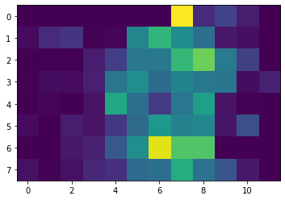

```python
import matplotlib.pyplot as plt
image = plt.imshow(data)
plt.show()
```

Los pixeles azulosos representan valores bajos y los más amarillos representan valores altos. Podemos ver que la precipitación es mayor en los meses de verano (5-9 del eje x). Veamos la precipitación mensual promedio de todos los años:

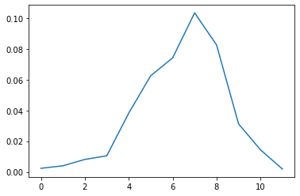

```python
prom_precip = numpy.mean(data, axis=0)
prom_plot = plt.plot(prom_precip)
plt.show()
```

Aqui pusimos la precipitación mensual promedio a lo largo de todos los años en la variable `prom_precip` y luego le pedimos a `matplotlib.pyplot` (`plt`) que creara y mostrara una gráfica de líneas de esos valores. El resutado muestra un incremento de la precipitación en los meses de verano. Veamos otras estadísticas:

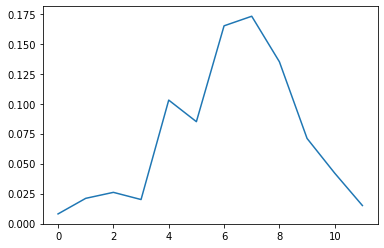

```python
max_plot = plt.plot(numpy.max(data,axis=0))
plt.show()
```

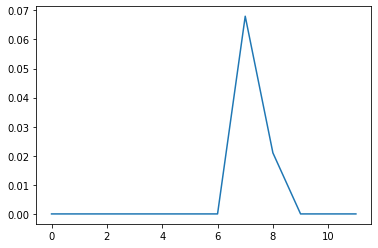

```python
min_plot = plt.plot(numpy.min(data,axis=0))
plt.show()
```

### 3.1 Grupos de gráficas

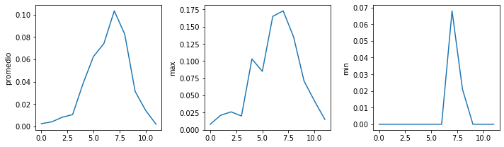

```python
# Este es un script completo - una unidad que importa las bibliotecas,
# lee los datos del archivo txt, calcula estadística y
# grafica los resultados

import numpy
import matplotlib.pyplot

data = numpy.loadtxt(fname='precip_mensual_estacion01.csv', delimiter=',')

fig = matplotlib.pyplot.figure(figsize=(10.0, 3.0))

axes1 = fig.add_subplot(1, 3, 1)
axes2 = fig.add_subplot(1, 3, 2)
axes3 = fig.add_subplot(1, 3, 3)

axes1.set_ylabel('promedio')
axes1.plot(numpy.mean(data, axis=0))

axes2.set_ylabel('max')
axes2.plot(numpy.max(data, axis=0))

axes3.set_ylabel('min')
axes3.plot(numpy.min(data, axis=0))

fig.tight_layout()

matplotlib.pyplot.savefig('precipitacion.png')
matplotlib.pyplot.show()
```

`fig.tight_layout()` le da espacio suficiente a las gráficas dentro de la figura para que no queden aplastadas. La llamada a `savefig` guarda la figura como un archivo gráfico que se puede usar en otros documentos, por ejemplo para ponerlo en sus reportes ;-)

El formato del archivo lo determina matplotlib automáticamente a partir de la extensión en el nombre que le dimos al archivo. En el programa anterior es PNG porque usamos el nombre 'precipitación.png', pero se puede usar PDF, SVG, JPG, EPS, etc.

### Ahora prueben ustedes

1. Crea una gráfica de la desviación estándar de la precipitacion mensual a lo largo de todos los años (axis=0). Agrega nombres a los ejes.
2. Modifica el progama anterior para que los límites de los ejes sean exactamente de 0 a 11 en x. Usa la función set_xlim(min, max) para lograrlo.
3. Modifica el progama anterior para que la figura muestre 3 subgráficas una encima de la otra en lugar de una a lado de la otra.

**Creo que había dos formas de interpretar "una gráfica encima de la otra", así que les dejo las dos soluciones:**

Solución 1:

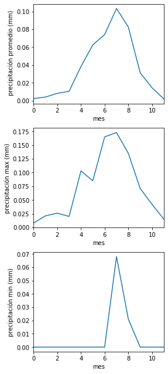

```python
# Este es un script completo - una unidad que importa las bibliotecas,
# lee los datos del archivo txt, calcula estadística y
# grafica los resultados

import numpy
import matplotlib.pyplot

data = numpy.loadtxt(fname='precip_mensual_estacion01.csv', delimiter=',')

fig = matplotlib.pyplot.figure(figsize=(4.0, 9.0))

axes1 = fig.add_subplot(3, 1, 1)
axes2 = fig.add_subplot(3, 1, 2)
axes3 = fig.add_subplot(3, 1, 3)

axes1.set_ylabel(' precipitación promedio (mm)')
axes1.plot(numpy.mean(data, axis=0))
axes1.set_xlim(0,11)
axes1.set_xlabel('mes')

axes2.set_ylabel('precipitación max (mm)')
axes2.plot(numpy.max(data, axis=0))
axes2.set_xlim(0,11)
axes2.set_xlabel('mes')

axes3.set_ylabel('precipitación min (mm)')
axes3.plot(numpy.min(data, axis=0))
axes3.set_xlabel('mes')
axes3.set_xlim(0,11)

fig.tight_layout()


matplotlib.pyplot.savefig('precipitacion.png')
matplotlib.pyplot.show()
```

Solución 2:

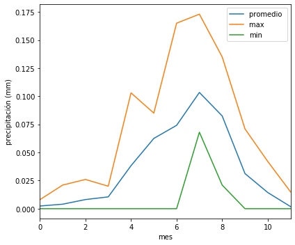

```python
# Este es un script completo - una unidad que importa las bibliotecas,
# lee los datos del archivo txt, calcula estadística y
# grafica los resultados

import numpy
import matplotlib.pyplot

data = numpy.loadtxt(fname='precip_mensual_estacion01.csv', delimiter=',')

fig = matplotlib.pyplot.figure(figsize=(6.0, 5.0))

axes1 = fig.add_subplot(1, 1, 1)

axes1.set_ylabel('precipitación (mm)')
axes1.plot(numpy.mean(data, axis=0), label='promedio ')
axes1.plot(numpy.max(data, axis=0), label='max ')
axes1.plot(numpy.min(data, axis=0), label='min')

axes1.set_xlim(0,11)
axes1.set_xlabel('mes')
axes1.legend()
fig.tight_layout()

matplotlib.pyplot.savefig('precipitacion.png')
matplotlib.pyplot.show()
```